# ESM 244 - HW4 - Task 1

Author

Lauren Puffer

## Overview

### Purpose of Analysis

With this analysis, we aim to assess possible temporal trends of Coho salmon, jack Coho salmon, and Steelhead trout in the Columbia River Basin. Our analysis will use time series data and daily fish counts gathered from the Columbia River DART to make visualizations and explore patterns in seasonality and overall trends, as well as compare temporal abundances across years for each fish type.

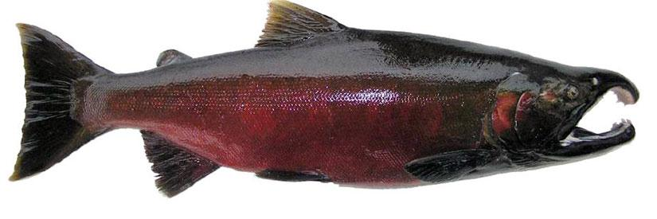

Male Coho salmon in breeding colors

[Male Coho salmon (courtesy of CA Sea Grant)](https://caseagrant.ucsd.edu/russian-river-salmon-steelhead/russian-river-learning-center/salmonid-identification)

### Data citation

Data were shared by and accessed from [Columbia River DART](http://www.cbr.washington.edu/dart/query/adult_graph_text) (Data Access in Real Time), accessed January 25, 2023. This data comes from a collaboration of 8 entities monitoring fish populations in the Columbia Basin. Fish counts for 9 species and water temperature are recorded daily.

### Pseudocode

1. Load necessary packages, including fable and feast
2. Read in the data and pivot longer to create distinct columns for type and count
3. Put data into a tsibble table for ease of use with time-series data
4. Plot daily counts of entire study to look for temporal trends in data
5. Convert data into week-year format and plot for seasonality
6. Convert data into year format and plot abundances across year

## Load packages

```r
library(tidyverse)
library(janitor)
library(here)
library(dplyr) #change NAs to zeros
library(tsibble) #make a dataframe
library(lubridate) #used for altering time series data
library(feasts)
library(fable)
library(patchwork)
```

## Data wrangling

Because we are working with time-series data, we need to make sure that all of our observations are in tidy form. This means NAs must be changed to zero values, each row must represent its own observation, and ‘date’ must be in the proper format (year-month-day).

```r
# load data from local file
fish_data <- read.csv(here("data", "willamette_fish_passage.csv")) |>
  clean_names() |>
  mutate_all(~replace(., is.na(.), 0))|>  #change NA values to zeros
  select(date, steelhead, coho, jack_coho)|>
  mutate(date = mdy(date))


#create a distinct dataframe with species in 1 column and fish count in another column
fish_data_long <- fish_data|>
  pivot_longer(cols = c(jack_coho, coho, steelhead),
               names_to= "type",
               values_to = "count")

# create a tsibbble table ofr usability
fish_ts <- fish_data_long |>
  as_tsibble(key = type, #not more than one variable dertmining time indeces
             index = date) #use date to specify time
```

## Overall Temporal Trends

In order to observe the general trends in the data, we must look at observations through a broader lens. For this reason, we will plot daily counts of jack Coho, Coho, and Steelhead by type across year. This will also us to make inferences about what could be governing the presence/absence and overall abundance of each fish type in the Columbia River Basin.

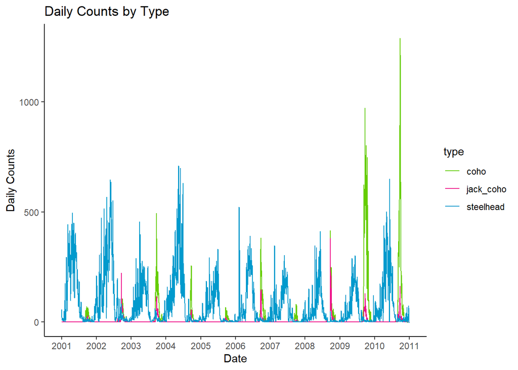

Fig. 1 - Daily fish counts for adult Steelhead trout, jack Coho salmon, and Coho salmon observed in the Columbia River Basin.

```r
ggplot(data = fish_ts,
       aes(x = date, y = count, colour = type)) +
  geom_line() +
  labs(x = "Date",
       y = "Daily Counts",
       title = "Daily Counts by Type") +
  scale_color_manual(values = c("steelhead" = "deepskyblue3",
                                "jack_coho" = "deeppink2",
                                "coho" = "chartreuse3")) +
    scale_x_date(date_breaks = "1 year", date_labels = "%Y") +
  theme_classic()
```

## Seasonality

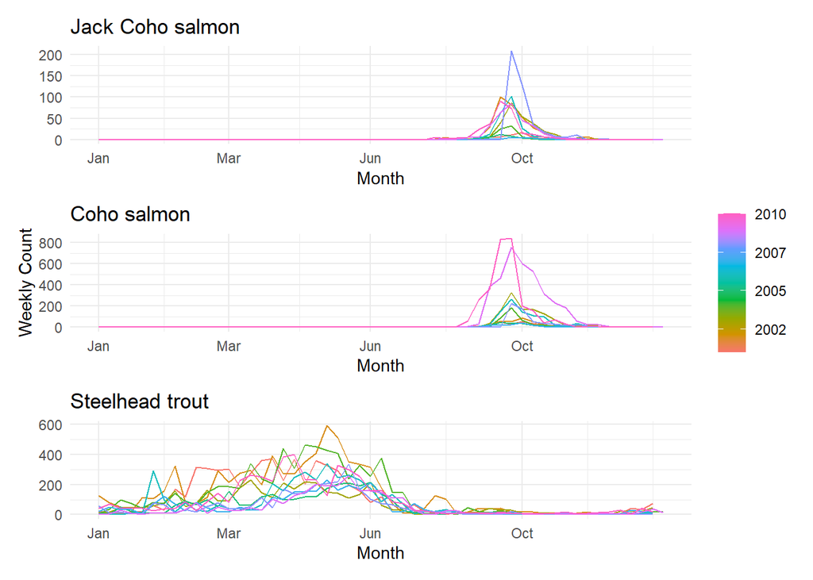

Fig. 2 - Weekly abundances for adult jack Coho salmon, Coho salmon, and Steelhead trout observed in the Columbia River Basin across study years. Note: Range of count values varies. Data across type are not scaled.

```r
# weekly coho jack
jack_week <- fish_ts |>
  filter(type == "jack_coho") |>
  index_by(week = ~yearweek(.)) |> #use yearweek to convert date
  summarize(weekly_count = mean(count, na.rm = TRUE)) |>
      ungroup()

#plots seasonal average across year
jack_season <- jack_week|>
  gg_season(y = weekly_count) +
  geom_line() +
  labs(x = "Month", y = "", title= "Jack Coho salmon") +
  theme_minimal() +
  theme(legend.position = "none")


#do the same for coho
coho_week <- fish_ts |>
  filter(type == "coho") |>
  index_by(week = ~yearweek(.)) |> #use yearweek to convert date
  summarize(weekly_count = mean(count, na.rm = TRUE)) |>
      ungroup()

#plots seasonal average across year
coho_season <- coho_week|>
  gg_season(y = weekly_count) +
  geom_line() +
  labs(x = "Month", y = "Weekly Count", title = "Coho salmon") +
  theme_minimal()

#do the same for steelhead
steelhead_week <- fish_ts |>
  filter(type == "steelhead") |>
  index_by(week = ~yearweek(.)) |> #use yearweek to convert date
  summarize(weekly_count = mean(count, na.rm = TRUE)) |>
      ungroup()

#plots seasonal average across year
steelhead_season <- steelhead_week |>
  gg_season(y = weekly_count) +
  geom_line() +
  labs(x = "Month", y = "", title = "Steelhead trout") +
  theme_minimal() +
  theme(legend.position = "none")

patch <- jack_season/coho_season/steelhead_season

print(patch)
```

### Explanation of trends

- There is much more variation in weekly Steelhead trout abundance compared with jack Coho and Coho salmon in the first half of the year. Steelhead trout tend to maintain higher abundances for a larger portion of the year compared with the Coho salmon. This trend may be explained by the fact that Coho salmon must leave the river when they reach maturity, and they don’t return until it is time for them to breed. Steelhead, on the other hand, do not have to leave the river at any particular time. A Steelhead that remains in the river its whole life is effectively what we call a Rainbow trout.
- Steelhead and Coho have different reproduction strategies. Salmon reproduce only once and only make 1 journey to the ocean before returning to spawn. After the salmon spawn, they die. Steelhead can go back and forth from the ocean and can breed more than once. The larger abundance of Steelhead could be explained by this unique life history strategy.
- This data was collected at a “fish ladder” in Willamette Falls. This is important to note because fish ladders are a type of fish passages used to aid in the migration of anadromous fishes like Coho and Steelhead. Salmon (like Coho) have certain seasons when they “run” from river to ocean or ocean to river. The spike in observations of both types of Coho salmon likely corresponds with the Salmon run season, which occurs in the fall for Coho salmon.

## Annual Counts

In order to observe how fish abundances for jack Coho, Coho, and Steelhead are changing over time, we will plot their abundance for each year across the 10 years of the study. We will use a stacked bar graph to illustrate these trends.

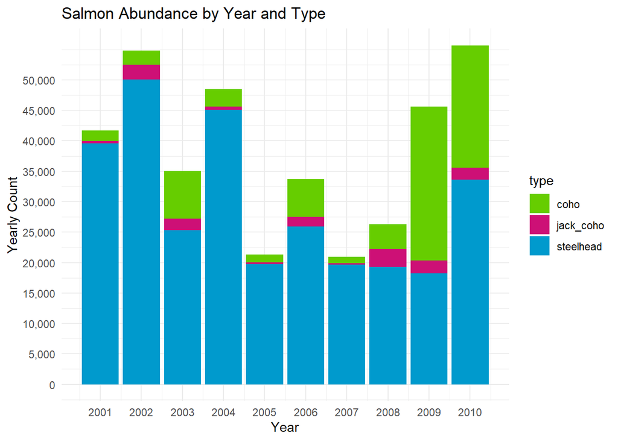

Fig. 3 - Annual abundances for adult jack Coho salmon, Coho salmon, and Steelhead trout observed in the Columbia River Basin across study years.

```r
#create a dataframe with salmon type, yearly count, and year
fish_year <- fish_ts |>
  group_by(type) |>  #Group by 'type' before summarizing
  index_by(year = ~year(.)) |> #get time series data by year (10 years)
  summarize(yearly_count = sum(count, na.rm = TRUE)) |> #create yearly count column
  ungroup()

#create bar graph of abundance by year colored by 'type'
fish_year_abundance <- ggplot(fish_year, aes(x = year, y = yearly_count, fill = type)) +
  geom_col(stat = "identity") +
  labs(x = "Year", y = "Yearly Count", title = "Salmon Abundance by Year and Type") +
  scale_x_continuous(breaks = seq(min(fish_year$year), max(fish_year$year), by = 1)) + # Continuous x-axis
  scale_y_continuous(
    breaks = seq(0, max(fish_year$yearly_count), by = 5000),
    labels = scales::comma_format() #semi-continuous y axis
  ) +
  scale_fill_manual(values = c("chartreuse3", "deeppink3", "deepskyblue3")) +
  theme_minimal()

  fish_year_abundance
```

## Discussion

When establishing policies to improve the overall abundances of these species, it is important to consider their life history strategies. Time-series data like this can also inform the fishing practices and natural resource use regulations of the area to minimize impact on the environment. Future analysis should explore data collected over a period which is longer than 10 years, specifically to explain the variation in Steelhead trout.